# DA Lab8_HW

Na SeungChan

2023-11-13

# Exercises

In this exercise, we will generate simulated data, and will then use this data to perform the best subset selection.

## (a)

Use the `rnorm` function to generate a predictor $X$ of length $n = 100$ with mean and variance of what you want. Also, generate a noise vector $\epsilon$ of length $n = 100$ from standard normal distribution (mean 0 and variance 1).

```r
vec_x <- rnorm(n = 100, mean = 10, sd = 5)
vec_error <- rnorm(n = 100, mean = 0, sd = 1)
```

## (b)

Generate a response vector $Y$ of length $n = 100$ according to the model
$$Y = \beta_0 + \beta_1X + \beta_2X^2 + \beta_3X^3 + \epsilon,$$
where $\beta_0$, $\beta_1$, $\beta_2$, and $\beta_3$ are constants of your choice.

```r
betas <- round(10*rbeta(n = 4, 5, 10), 2) - 5
betas
```

```
## [1] -3.97 -1.19  0.21 -3.36
```

```r
y <- betas[1] + betas[2]*vec_x + betas[3]*(vec_x)^2 + betas[4]*(vec_x)^3 + vec_error
df <- data.frame(vec_x, y)
```

##(c)

Use the `regsubsets()` function to perform the best subset selection in order to choose the best model containing the predictors $X, X^2, \dots, X^{10}$. What is the best model obtained according to $C_p$, BIC, and adjusted $R^2$? Show some plots to provide evidence for your answer, and report the coefficients of the best model obtained. Note you will need to use the `data.frame()` function to create a single data set containing both $X$ and $Y$.

```r
full_model <- regsubsets(y ~ poly(vec_x, degree = 10), data = df, nvmax = 11)
summary(full_model)
```

```
## Subset selection object
## Call: regsubsets.formula(y ~ poly(vec_x, degree = 10), data = df, nvmax = 11)
## 10 Variables  (and intercept)
##                            Forced in Forced out
## poly(vec_x, degree = 10)1      FALSE      FALSE
## poly(vec_x, degree = 10)2      FALSE      FALSE
## poly(vec_x, degree = 10)3      FALSE      FALSE
## poly(vec_x, degree = 10)4      FALSE      FALSE
## poly(vec_x, degree = 10)5      FALSE      FALSE
## poly(vec_x, degree = 10)6      FALSE      FALSE
## poly(vec_x, degree = 10)7      FALSE      FALSE
## poly(vec_x, degree = 10)8      FALSE      FALSE
## poly(vec_x, degree = 10)9      FALSE      FALSE
## poly(vec_x, degree = 10)10     FALSE      FALSE
## 1 subsets of each size up to 10
```

[output cut: 56 more lines]

```r
summary_fm <- summary(full_model)
summary_fm$cp
```

```
##  [1] 1.534453e+09 1.189755e+08 2.131829e+01 1.719928e+01 1.333281e+01
##  [6] 9.703775e+00 9.032314e+00 9.147428e+00 9.275752e+00 1.100000e+01
```

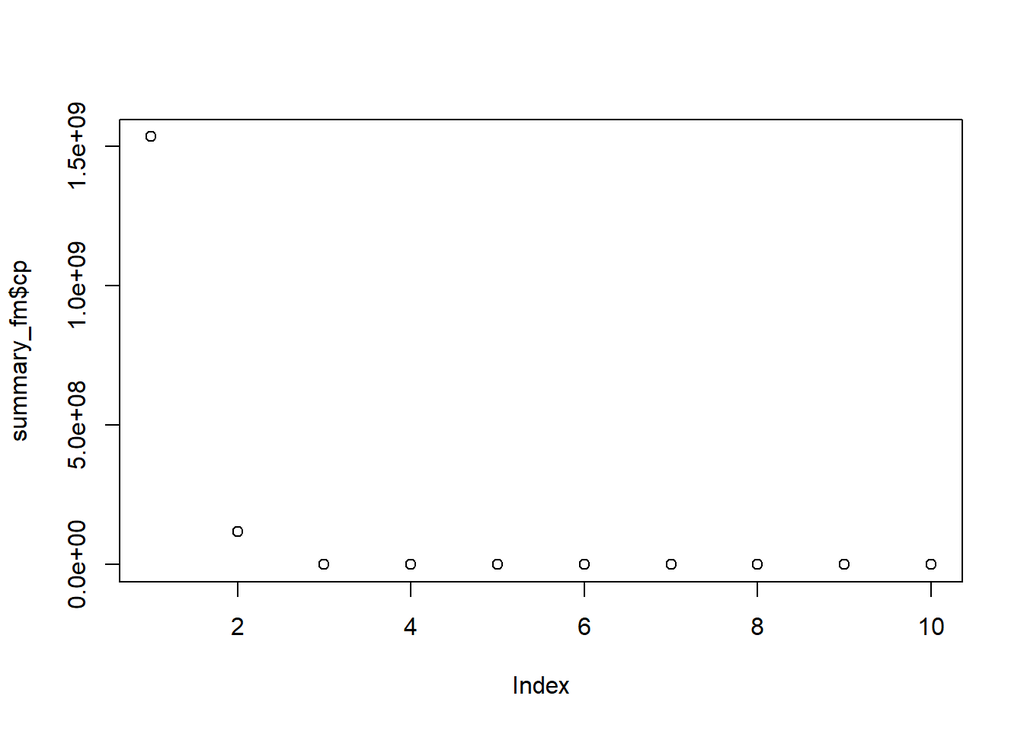

```r
plot(summary_fm$cp)
```

```r
summary_fm$bic
```

```
##  [1]  -125.2576  -376.3535 -1758.1711 -1759.1171 -1760.1398 -1761.2499
##  [7] -1759.4758 -1756.9175 -1754.3872 -1750.0914
```

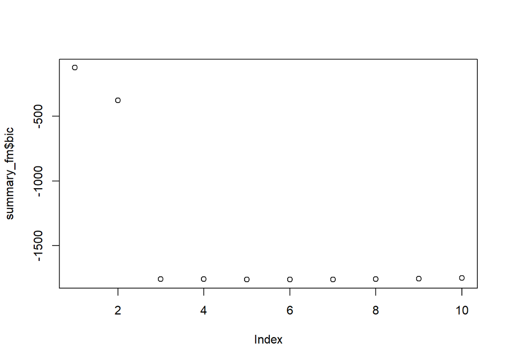

```r
plot(summary_fm$bic)
```

```r
summary_fm$adjr2
```

```
##  [1] 0.7367172 0.9793756 1.0000000 1.0000000 1.0000000 1.0000000 1.0000000
##  [8] 1.0000000 1.0000000 1.0000000
```

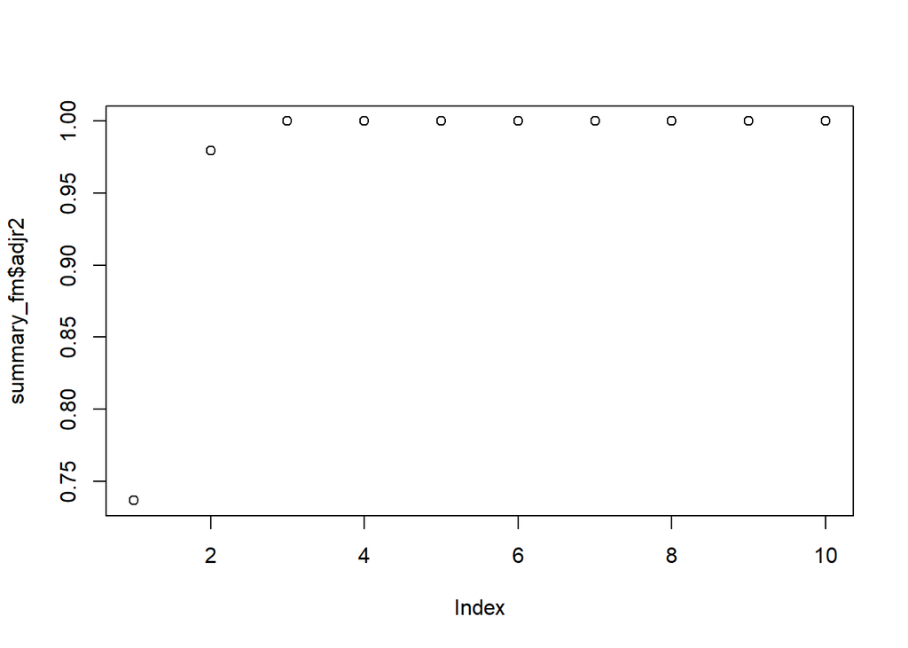

```r
plot(summary_fm$adjr2)
```

```r
coef(full_model, 1)
```

```
##               (Intercept) poly(vec_x, degree = 10)1
##                 -6042.346                -55703.178
```

```r
coef(full_model, 2)
```

```
##               (Intercept) poly(vec_x, degree = 10)1 poly(vec_x, degree = 10)2
##                 -6042.346                -55703.178                -31763.505
```

(??) BIC랑 $C_p$ 그래프 모양이 좀 이상한데(수업의 전형적 결과랑 다름)… 코딩을 잘못해서 이리 된 건가? 아니면 모의실험으로 생성된 데이터 특성상 이런 결과물이 나올 수도 있는 건가?

## (d)

Repeat (c), using forward stepwise selection and also using backward stepwise selection. How does your answer compare to the results in (c)?

```r
forward_model <- regsubsets(y ~ poly(vec_x, degree = 10), data = df, nvmax = 11, method = "forward")
summary(forward_model)
```

```
## Subset selection object
## Call: regsubsets.formula(y ~ poly(vec_x, degree = 10), data = df, nvmax = 11,
##     method = "forward")
## 10 Variables  (and intercept)
##                            Forced in Forced out
## poly(vec_x, degree = 10)1      FALSE      FALSE
## poly(vec_x, degree = 10)2      FALSE      FALSE
## poly(vec_x, degree = 10)3      FALSE      FALSE
## poly(vec_x, degree = 10)4      FALSE      FALSE
## poly(vec_x, degree = 10)5      FALSE      FALSE
## poly(vec_x, degree = 10)6      FALSE      FALSE
## poly(vec_x, degree = 10)7      FALSE      FALSE
## poly(vec_x, degree = 10)8      FALSE      FALSE
## poly(vec_x, degree = 10)9      FALSE      FALSE
## poly(vec_x, degree = 10)10     FALSE      FALSE
```

[output cut: 57 more lines]

```r
summary_fom <- summary(forward_model)
summary_fom$cp
```

```
##  [1] 1.534453e+09 1.189755e+08 2.131829e+01 1.719928e+01 1.333281e+01
##  [6] 9.703775e+00 9.032314e+00 9.147428e+00 9.275752e+00 1.100000e+01
```

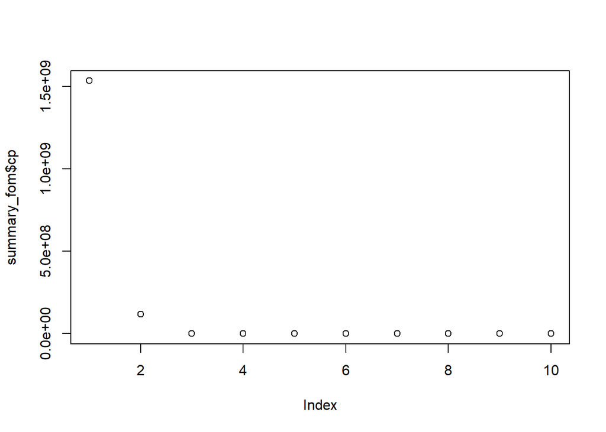

```r
plot(summary_fom$cp)
```

```r
summary_fom$bic
```

```
##  [1]  -125.2576  -376.3535 -1758.1711 -1759.1171 -1760.1398 -1761.2499
##  [7] -1759.4758 -1756.9175 -1754.3872 -1750.0914
```

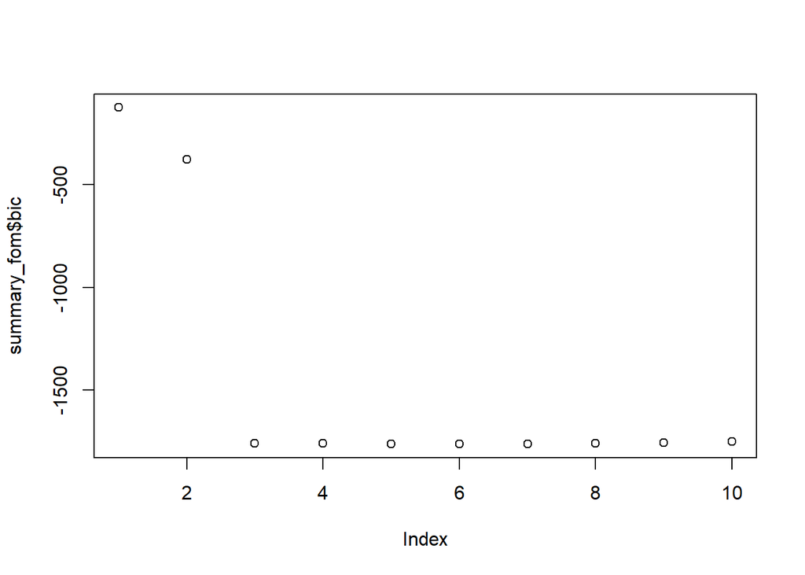

```r
plot(summary_fom$bic)
```

```r
summary_fom$adjr2
```

```
##  [1] 0.7367172 0.9793756 1.0000000 1.0000000 1.0000000 1.0000000 1.0000000
##  [8] 1.0000000 1.0000000 1.0000000
```

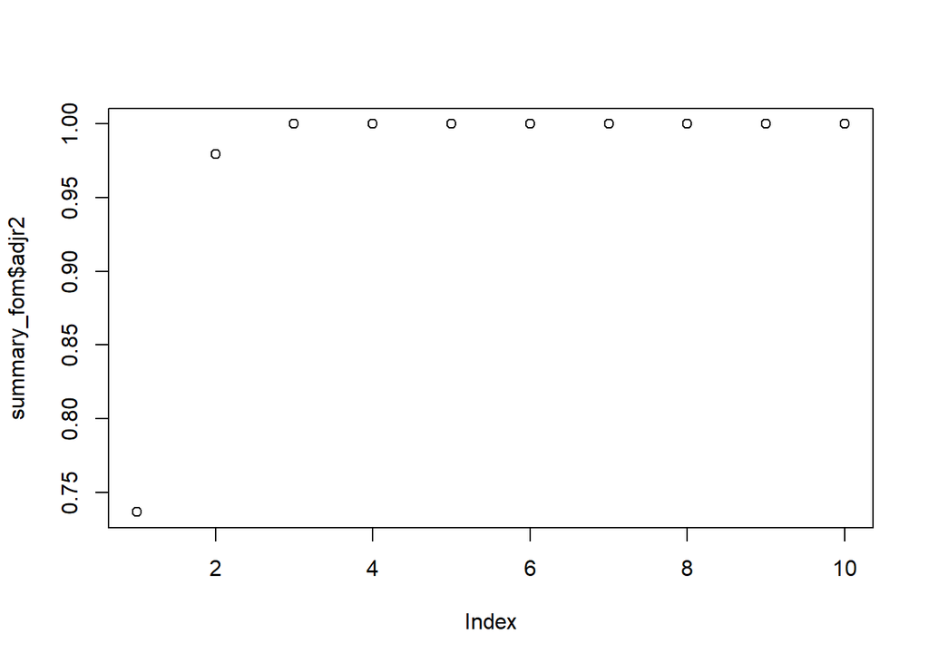

```r
plot(summary_fom$adjr2)
```

```r
coef(forward_model, 1)
```

```
##               (Intercept) poly(vec_x, degree = 10)1
##                 -6042.346                -55703.178
```

```r
coef(forward_model, 2)
```

```
##               (Intercept) poly(vec_x, degree = 10)1 poly(vec_x, degree = 10)2
##                 -6042.346                -55703.178                -31763.505
```

```r
backward_model <- regsubsets(y ~ poly(vec_x, degree = 10), data = df, nvmax = 11, method = "backward")
summary(backward_model)
```

```
## Subset selection object
## Call: regsubsets.formula(y ~ poly(vec_x, degree = 10), data = df, nvmax = 11,
##     method = "backward")
## 10 Variables  (and intercept)
##                            Forced in Forced out
## poly(vec_x, degree = 10)1      FALSE      FALSE
## poly(vec_x, degree = 10)2      FALSE      FALSE
## poly(vec_x, degree = 10)3      FALSE      FALSE
## poly(vec_x, degree = 10)4      FALSE      FALSE
## poly(vec_x, degree = 10)5      FALSE      FALSE
## poly(vec_x, degree = 10)6      FALSE      FALSE
## poly(vec_x, degree = 10)7      FALSE      FALSE
## poly(vec_x, degree = 10)8      FALSE      FALSE
## poly(vec_x, degree = 10)9      FALSE      FALSE
## poly(vec_x, degree = 10)10     FALSE      FALSE
```

[output cut: 57 more lines]

```r
summary_ba <- summary(backward_model)
summary_ba$cp
```

```
##  [1] 1.534453e+09 1.189755e+08 2.131829e+01 1.719928e+01 1.333281e+01
##  [6] 9.703775e+00 9.032314e+00 9.147428e+00 9.275752e+00 1.100000e+01
```

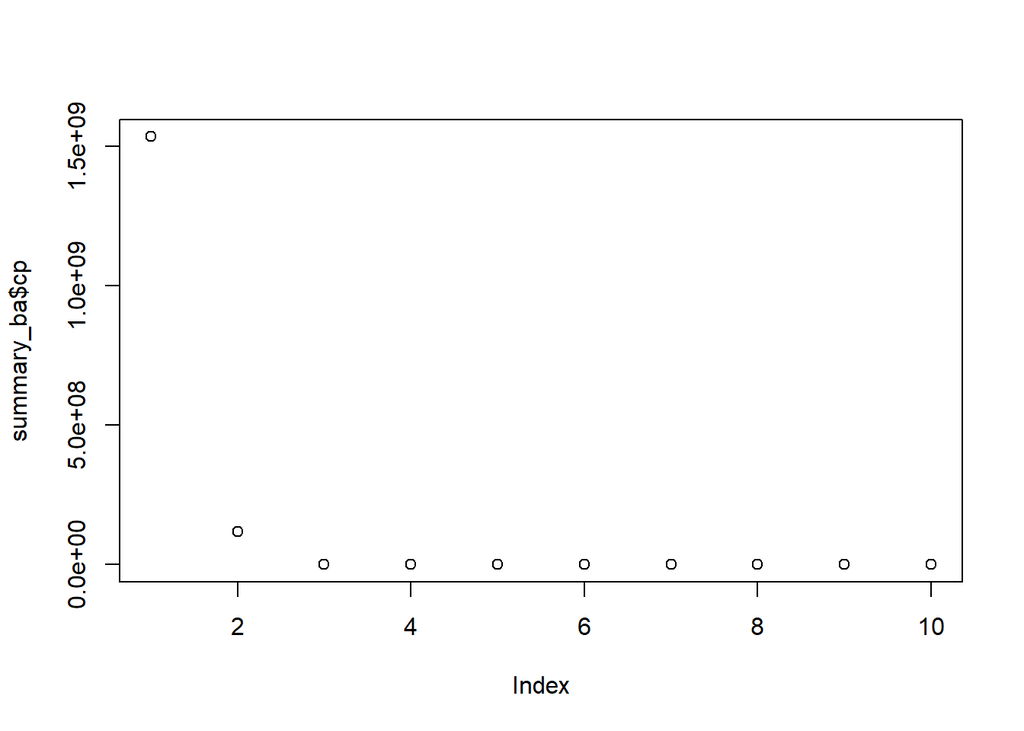

```r
plot(summary_ba$cp)
```

```r
summary_ba$bic
```

```
##  [1]  -125.2576  -376.3535 -1758.1711 -1759.1171 -1760.1398 -1761.2499
##  [7] -1759.4758 -1756.9175 -1754.3872 -1750.0914
```

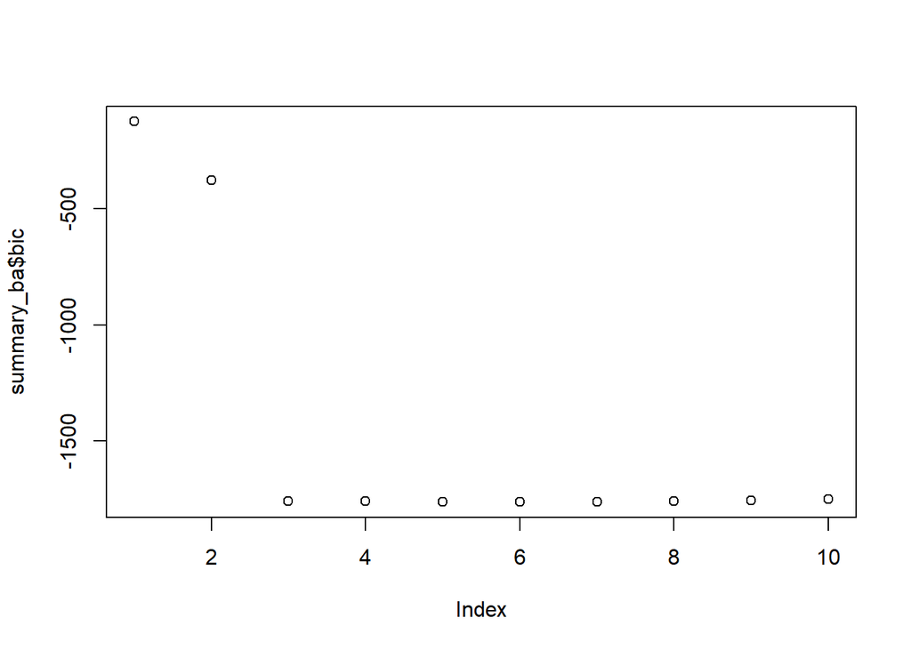

```r
plot(summary_ba$bic)
```

```r
summary_ba$adjr2
```

```
##  [1] 0.7367172 0.9793756 1.0000000 1.0000000 1.0000000 1.0000000 1.0000000
##  [8] 1.0000000 1.0000000 1.0000000
```

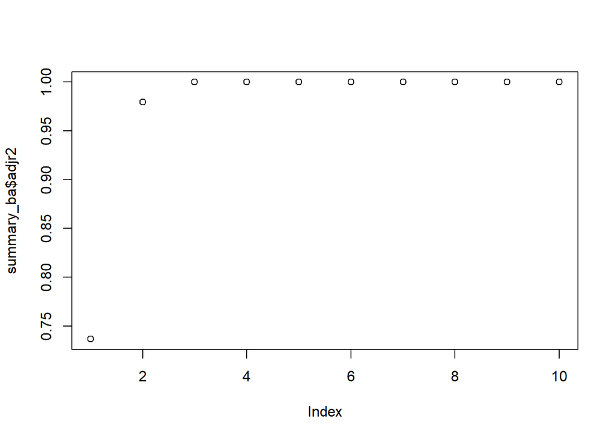

```r
plot(summary_ba$adjr2)
```

```r
coef(backward_model, 1)
```

```
##               (Intercept) poly(vec_x, degree = 10)1
##                 -6042.346                -55703.178
```

```r
coef(backward_model, 2)
```

```
##               (Intercept) poly(vec_x, degree = 10)1 poly(vec_x, degree = 10)2
##                 -6042.346                -55703.178                -31763.505
```

같게 나왔다. 최종 모델이 많이 단순하면 이런 결과가 나올 수 있는 건가…?

## (e)

Now fit a lasso model to the simulated data, again using $X, X^2, \dots, X^{10}$ as predictors. Use cross-validation to select the optimal value of $\lambda$. Create plots of the cross-validation to select the optimal value of $\lambda$. Create plots of the cross-validation error as a function of $\lambda$. Report the resulting coefficient estimates, and discuss the results obtained.

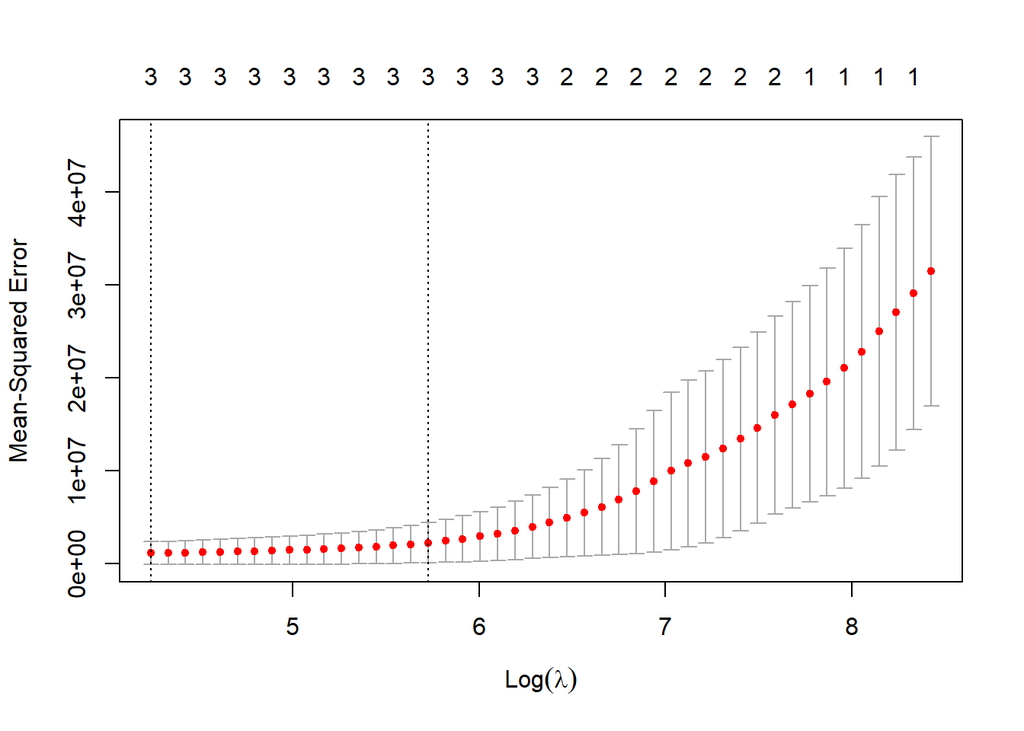

```r
x_glm <- model.matrix(y ~ poly(vec_x, degree = 10), data = df)[, -1]
y_glm <- y
df_tr <- sample(c(TRUE, FALSE), nrow(df), replace = TRUE)
df_te <- (!df_tr)

md_qe_out <- cv.glmnet(x_glm[df_tr,], y_glm[df_tr], alpha = 1)
plot(md_qe_out)
```

```r
bestl <- md_qe_out$lambda.min
la_pr <- predict(md_qe_out, s = bestl, newx = x_glm[df_te,])
mean((la_pr - y_glm[df_te])^2)#test MSE
```

```
## [1] 58152.36
```

```r
coef(md_qe_out, bestl)
```

```
## 11 x 1 sparse Matrix of class "dgCMatrix"
##                                    s1
## (Intercept)                 -6011.206
## poly(vec_x, degree = 10)1  -54622.198
## poly(vec_x, degree = 10)2  -30403.033
## poly(vec_x, degree = 10)3   -8123.291
## poly(vec_x, degree = 10)4       .
## poly(vec_x, degree = 10)5       .
## poly(vec_x, degree = 10)6       .
## poly(vec_x, degree = 10)7       .
## poly(vec_x, degree = 10)8       .
## poly(vec_x, degree = 10)9       .
## poly(vec_x, degree = 10)10      .
```

## (f)

Now generate a response vector $Y$ according to the model
$$Y = \beta_0 + \beta_7X^7 + \epsilon$$
and perform the best subset selection and the lasso. Discuss the results obtained.

```r
y_7 <- betas[1] + rpois(1, lambda = 5)*(vec_x)^7 + vec_error
```

그런데 무슨 모델에 대해서 best subset selection and lasso를 하라는 것인지 명시되지 않았다. 일단 계숙 했던 10차 다항회귀 모델에 대해 수행하였다.

```r
df_7 <- data.frame(vec_x, y_7) %>%
  rename("x_7" = "vec_x")


full_model_7 <- regsubsets(y_7 ~ poly(x_7, degree = 10), data = df_7, nvmax = 10)
summary(full_model_7)
```

```
## Subset selection object
## Call: regsubsets.formula(y_7 ~ poly(x_7, degree = 10), data = df_7,
##     nvmax = 10)
## 10 Variables  (and intercept)
##                          Forced in Forced out
## poly(x_7, degree = 10)1      FALSE      FALSE
## poly(x_7, degree = 10)2      FALSE      FALSE
## poly(x_7, degree = 10)3      FALSE      FALSE
## poly(x_7, degree = 10)4      FALSE      FALSE
## poly(x_7, degree = 10)5      FALSE      FALSE
## poly(x_7, degree = 10)6      FALSE      FALSE
## poly(x_7, degree = 10)7      FALSE      FALSE
## poly(x_7, degree = 10)8      FALSE      FALSE
## poly(x_7, degree = 10)9      FALSE      FALSE
## poly(x_7, degree = 10)10     FALSE      FALSE
```

[output cut: 57 more lines]

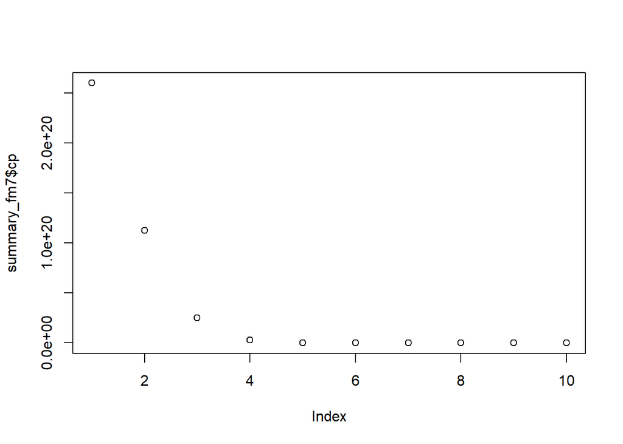

```r
summary_fm7 <- summary(full_model_7)
plot(summary_fm7$cp)
```

```r
which.min(summary_fm7$cp)
```

```
## [1] 9
```

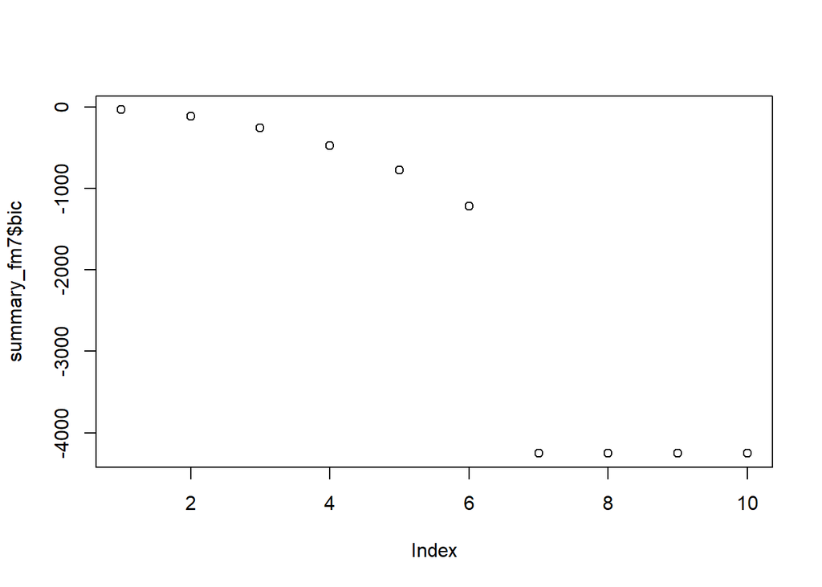

```r
plot(summary_fm7$bic)
```

```r
which.min(summary_fm7$bic)
```

```
## [1] 9
```

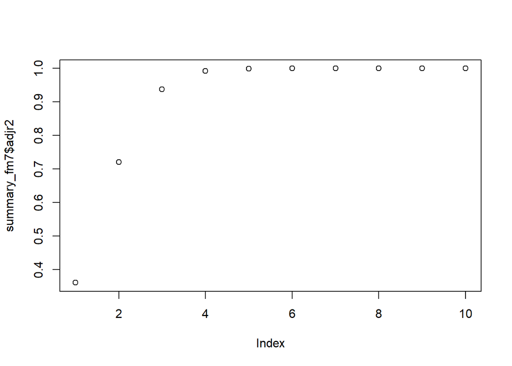

```r
plot(summary_fm7$adjr2)
```

```r
which.max(summary_fm7$adjr2)
```

```
## [1] 7
```

```r
coef(full_model, 7)
```

```
##               (Intercept) poly(vec_x, degree = 10)1 poly(vec_x, degree = 10)2
##              -6042.345516             -55703.178144             -31763.505476
## poly(vec_x, degree = 10)3 poly(vec_x, degree = 10)6 poly(vec_x, degree = 10)7
##              -9208.857548                 -1.379912                  2.044867
## poly(vec_x, degree = 10)8 poly(vec_x, degree = 10)9
##                 -2.088420                  2.003061
```

```r
coef(full_model, 8)
```

```
##               (Intercept) poly(vec_x, degree = 10)1 poly(vec_x, degree = 10)2
##              -6042.345516             -55703.178144             -31763.505476
## poly(vec_x, degree = 10)3 poly(vec_x, degree = 10)5 poly(vec_x, degree = 10)6
##              -9208.857548                 -1.159096                 -1.379912
## poly(vec_x, degree = 10)7 poly(vec_x, degree = 10)8 poly(vec_x, degree = 10)9
##                  2.044867                 -2.088420                  2.003061
```

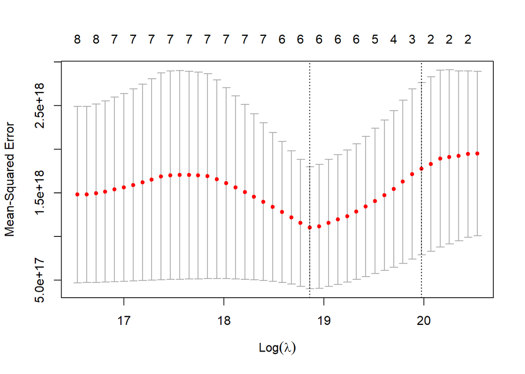

```r
x_glm_7 <- model.matrix(y_7 ~ poly(x_7, degree = 10), data = df_7)[, -1]
y_glm_7 <- y_7
df_tr7 <- sample(c(TRUE, FALSE), nrow(df_7), replace = TRUE)
df_te7 <- (!df_tr7)

q7_out <- cv.glmnet(x_glm_7[df_tr7,], y_glm_7[df_tr7], alpha = 1)
plot(q7_out)
```

```r
bestl7 <- q7_out$lambda.min
la_pr7 <- predict(q7_out, s = bestl7, newx = x_glm_7[df_te7,])
mean((la_pr7 - y_glm_7[df_te7])^2)#test MSE
```

```
## [1] 1.398868e+18
```

```r
coef(q7_out, bestl7)
```

```
## 11 x 1 sparse Matrix of class "dgCMatrix"
##                                   s1
## (Intercept)                686713481
## poly(x_7, degree = 10)1   6249986055
## poly(x_7, degree = 10)2   7736601468
## poly(x_7, degree = 10)3   2829617701
## poly(x_7, degree = 10)4            .
## poly(x_7, degree = 10)5            .
## poly(x_7, degree = 10)6  -2124252018
## poly(x_7, degree = 10)7   -579576673
## poly(x_7, degree = 10)8  -1366790884
## poly(x_7, degree = 10)9            .
## poly(x_7, degree = 10)10           .
```